# R Notebook

```r
liquor <- read_csv("data/story-sales/Iowa_Liquor_Sales-Story.csv")
```

Separate the lat/long data and make a new column for type of liquor (Charlotte):

County had both “Story” and “STORY”

Story county map so that we can plot the lat/long of all of Story county.

[figure not shown]

[figure not shown]

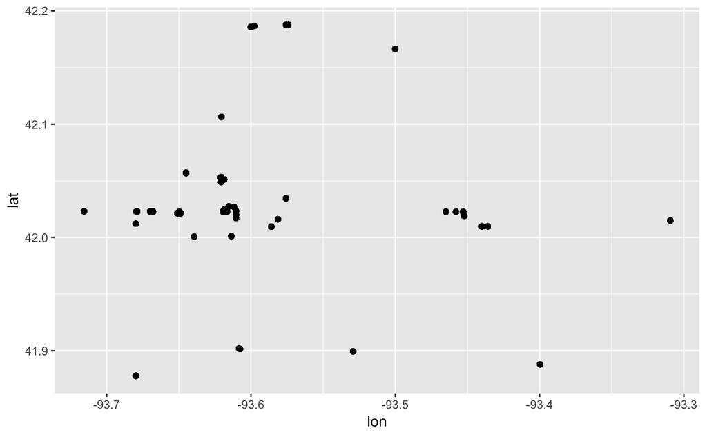

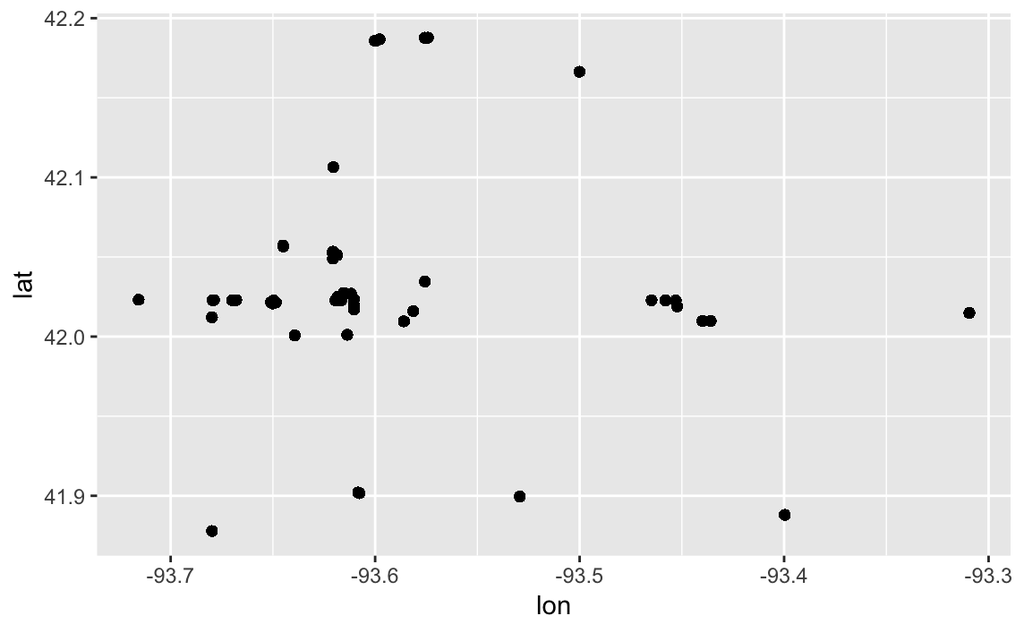

We decided to drop a lot of the columns to reduce the dataset. We may choose to pick some back up at a later date, but this should help with the size of the data.

```r
liquor_clean <- liquor %>%
  select(-c(`Invoice/Item Number`,`Store Number`,Address,`Zip Code`,`Store Location`,`County Number`,County,`Category Name`,`Vendor Number`,`Item Number`,coord.data,Category,`Item Description`,`Volume Sold (Gallons)`,`Volume Sold (Liters)`,`Sale (Dollars)`,`Bottles Sold`,`State Bottle Retail`,`State Bottle Cost`,`Bottle Volume (ml)`,Pack))
write_csv(liquor_clean,"data/liquor_cleanForSpatial.csv",col_names = TRUE)
```